# Project: Stable Matchmaking Algorithms

CAPIEU Valentin, HUCORNE Thomas & TOURNIER Valentin

2025-12-09

# Installing and Loading the package

```r
# libraries

if (!requireNamespace("CHTpackage", quietly = TRUE)) {
  if (!requireNamespace("remotes", quietly = TRUE)) {
    install.packages("remotes")
  }
  remotes::install_github("ThomasHucorne/MatchmakingProject/CHTpackage")

}

library(CHTpackage)
library(ggplot2)
```

# Problem description

Implémente plusieurs algorithmes pour résoudre le problème de matchmaking stable entre deux ensembles (hommes et femmes). Comprend une version naïve de l’algorithme de Gale-Shapley, une variante en choissisant les meilleurs d’abord (en prenant en compte les premiers choix des hommes comme base) basée sur une liste/ vectuer. Enfin un algorithme appliqué au domaine de la santé, avec ainsi des contraintes bien précises dedans.

# Defining Preferences

```r
# Example 1 preference lists

men_prefs <- list(
  Camille = c("Bérénice", "Prudence", "Lila", "Sarah", "Elodie"),
  Gérard  = c("Sarah", "Elodie", "Lila", "Prudence", "Bérénice"),
  Thibault = c("Lila", "Bérénice", "Elodie", "Sarah", "Prudence"),
  Sacha   = c("Elodie", "Lila", "Prudence", "Bérénice", "Sarah"),
  Jérôme  = c("Prudence", "Sarah", "Elodie", "Lila", "Bérénice")
)

women_prefs <- list(
  Bérénice = c("Gérard", "Camille", "Sacha", "Thibault", "Jérôme"),
  Prudence = c("Sacha", "Jérôme", "Camille", "Gérard", "Thibault"),
  Lila     = c("Camille", "Thibault", "Jérôme", "Sacha", "Gérard"),
  Sarah    = c("Thibault", "Sacha", "Gérard", "Jérôme", "Camille"),
  Elodie   = c("Jérôme", "Camille", "Thibault", "Gérard", "Sacha")
)
```

# Algorithm 1 - Naive Gale-Shapley

```r
result_gs <- gale_shapley(men_prefs, women_prefs)
result_gs
```

```
##               Man    Woman
## Bérénice  Camille Bérénice
## Sarah      Gérard    Sarah
## Lila     Thibault     Lila
## Elodie      Sacha   Elodie
## Prudence   Jérôme Prudence
```

# Algorithm 2 - Gale-Shapley with Bucket

```r
result_bucket <- best_gs_bucket(men_prefs, women_prefs)
result_bucket
```

```
##        Man    Woman
## 1  Camille Bérénice
## 2   Gérard    Sarah
## 3 Thibault     Lila
## 4    Sacha   Elodie
## 5   Jérôme Prudence
```

```r
# Example 2
men_prefs_1 <- list(
  Camille  = c("Bérénice", "Prudence", "Lila", "Sarah", "Elodie"),
  Gérard   = c("Bérénice", "Prudence", "Lila", "Sarah", "Elodie"),
  Thibault = c("Bérénice", "Prudence", "Lila", "Sarah", "Elodie"),
  Sacha    = c("Bérénice", "Prudence", "Lila", "Sarah", "Elodie"),
  Jérôme   = c("Bérénice", "Prudence", "Lila", "Sarah", "Elodie")
)

women_prefs_1 <- list(
  Bérénice = c("Jérôme", "Sacha", "Thibault", "Gérard", "Camille"),
  Prudence = c("Jérôme", "Sacha", "Thibault", "Gérard", "Camille"),
  Lila     = c("Jérôme", "Sacha", "Thibault", "Gérard", "Camille"),
  Sarah    = c("Jérôme", "Sacha", "Thibault", "Gérard", "Camille"),
  Elodie   = c("Jérôme", "Sacha", "Thibault", "Gérard", "Camille")
)
```

Algorithm 1 - Naive Gale-Shapley

```r
result_gs_1 <- gale_shapley(men_prefs_1, women_prefs_1)
result_gs_1
```

```
##               Man    Woman
## Bérénice   Jérôme Bérénice
## Prudence    Sacha Prudence
## Lila     Thibault     Lila
## Sarah      Gérard    Sarah
## Elodie    Camille   Elodie
```

Algorithm 2 - Gale-Shapley with Bucket

```r
result_bucket_1 <- best_gs_bucket(men_prefs_1, women_prefs_1)
result_bucket_1
```

```
##        Man    Woman
## 1  Camille   Elodie
## 2   Gérard    Sarah
## 3 Thibault     Lila
## 4    Sacha Prudence
## 5   Jérôme Bérénice
```

Algorithm3 - Hopcroft-Karp for Blood Donor Matching

```r
# Example blood type data
data <- data.frame(
  id = 1:6,
  blood_type = c("A+", "O-", "B+", "AB+", "AB-", "O+")
)
donors <- c(1, 2, 3)      # IDs of donors
receivers <- c(4, 5, 6)   # IDs of receivers
compatibility_table <- create_compatibility_table()
result_hk <- hopcroft_karp(donors, receivers, data, compatibility_table, can_receive)
print_matching_results(result_hk, donors, receivers, data)
```

```
##
## ========================================
## MATCHING RESULTS
## ========================================
##
## Total numbers of formed pairs : 2 / 3
## Satisfaction rate : 66.7%
##
## Formed pairs :
## ----------------
##  Donneur_ID Donneur_Type Receveur_ID Receveur_Type
##           1           A+           4           AB+
##           2           O-           5           AB-
##
##
## Unpaired donnors :
## ------------------------
## D3 (B+)
##
## Unsatisfied receivers :
## ---------------------------
## R6 (O+)
##
## ========================================
```

# Complexity

## Gale-Shapley

### Complexité théorique

Nous allons calculer théoriquement la complexité de l’algorithme de Gale-Shapley présent dans le ficher GaleShapley.R.

Tout d’abord, notons les complexité au sein des boucles. Notons $n$ le nombre d’homme (= nombre de femme aussi).

```r
gale_shapley <- function(men_prefs, women_prefs) {
  free_men <- names(men_prefs)    #O(1)
  engaged <- list()    #O(1)
  next_proposal <- setNames(rep(1, length(free_men)), free_men)    #O(1)

  # Helper function: rank of a man for a woman
  rank <- lapply(women_prefs, function(prefs) setNames(seq_along(prefs), prefs))    #O(n^2) n vector of size n

  while (length(free_men) > 0) {
    man <- free_men[1]    #O(1)
    woman <- men_prefs[[man]][next_proposal[man]]    #O(1)

    # Man proposes
    if (is.null(engaged[[woman]])) {    #O(1)
      engaged[[woman]] <- man    #O(1)
      free_men <- setdiff(free_men, man)    #O(n) worst case
    } else {    #O(1)
      current <- engaged[[woman]]    #O(1)
      if (rank[[woman]][[man]] < rank[[woman]][[current]]) {    #O(1)
        engaged[[woman]] <- man    #O(1)
        free_men <- c(free_men, current)    #O(1)
        free_men <- setdiff(free_men, man)    #O(n) worst case
      } else {    #O(1)
        # Woman rejects this man
      }
    }

    next_proposal[man] <- next_proposal[man] + 1    #O(1)
  }

  matches <- data.frame(    #O(1)
    Man = unlist(engaged),
    Woman = names(engaged),
    stringsAsFactors = FALSE
  )
  return(matches)    #O(1)
}
```

Concernant la boucle while, chaque homme fait sa demande aux femmes dans l’ordre de ses préférences et il ne peut faire sa demande qu’une seule fois.

Nous avons dans le pire des cas $n$ propositions par homme. Vu qu’il y a $n$ homme, cela ferait $n^2$ demandes. Il faut aussi prendre en compte le fait que setdiff() à une complexité linéaire sur la liste prise en argument. Sauf que dans ce cas de figure précis, la liste que setdiff prend en argument (free_men) se retrouverait quasiment vide presque tout le temps. On peut donc négliger sa complexité.

Ainsi :
$$C(\text{Gale-Shapley})=O(n^2)$$
### Complexité empirique

Voyons comment évolue le temps que met l’algorithme à tourner en fonction de $n$.

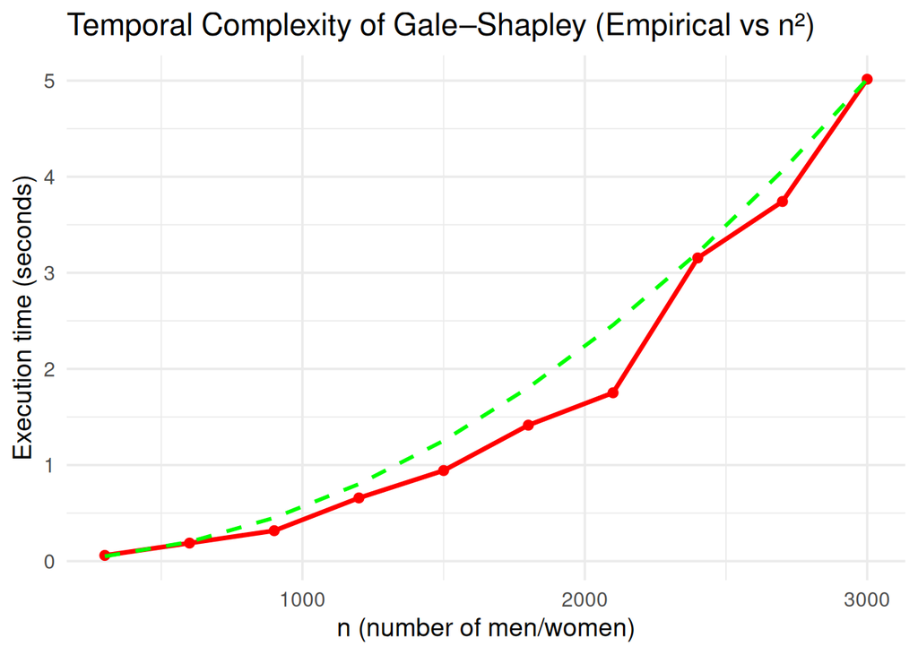

```r
# Choose sizes to test
sizes <- seq(300, 3000, by = 300)

# Measure runtime for each size
times <- sapply(sizes, test_gs_time)


# Build data frame for plotting
df <- data.frame(
  n = sizes,
  time = times,
  n_squared = (sizes^2) / max(sizes^2) * max(times) # scaled for comparison
)

# Plot measured time and n^2 curve
ggplot(df, aes(x = n)) +
  geom_line(aes(y = time), size = 1.2, color = 'red') +
  geom_point(aes(y = time), size = 2, color = 'red') +
  geom_line(aes(y = n_squared), linetype = "dashed", size = 1, color = 'green') +
  labs(
    title = "Temporal Complexity of Gale–Shapley (Empirical vs n²)",
    x = "n (number of men/women)",
    y = "Execution time (seconds)"
  ) +
  theme_minimal(base_size = 14)
```

On observe bien un temps d’execution quadratique, car si l’on plot avec une échelle logarithmique on observe bien une droite de pente égale à 2.

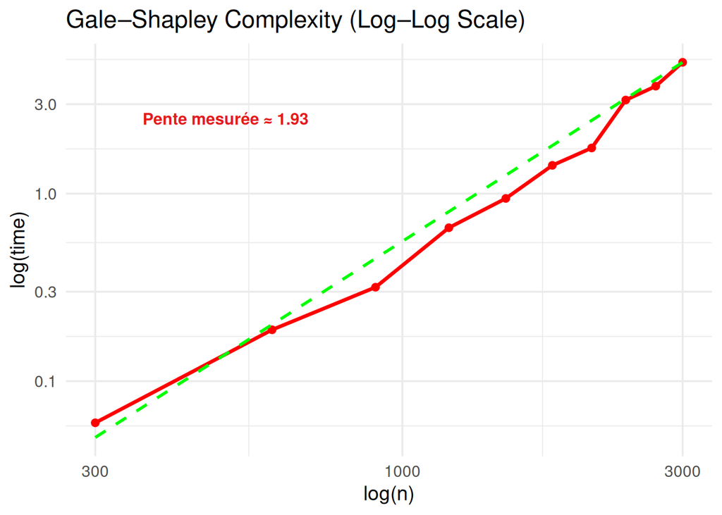

```r
log_time <- log10(df$time)
log_n <- log10(df$n)
model_time <- lm(log_time ~ log_n)
slope_time <- coef(model_time)[2]

ggplot(df, aes(x = n)) +
  geom_line(aes(y = time), size = 1.2, color = 'red') +
  geom_point(aes(y = time), size = 2, color = 'red') +
  geom_line(aes(y = n_squared), linetype = "dashed", size = 1, color = 'green') +
  labs(
    title = "Gale–Shapley Complexity (Log–Log Scale)",
    x = "log(n)",
    y = "log(time)"
  ) +
  scale_x_log10() +
  scale_y_log10() +
  theme_minimal(base_size = 14) +
  annotate("text", x = 500, y = max(df$time) * 0.5,
           label = sprintf("Pente mesurée ≈ %.2f", slope_time),
           color = "#E41A1C", size = 4, fontface = "bold")
```

## Gale-Shapley with buckets

### Theoritical Complexity

```r
best_gs_bucket <- function(men_prefs, women_prefs) {

  men_names   <- names(men_prefs)    # O(n)
  women_names <- names(women_prefs)       # O(n)

  n <- length(men_prefs)

  men_index   <- setNames(seq_len(n), men_names)     # O(n)
  women_index <- setNames(seq_len(n), women_names)    # O(n)

  men_pref_num <- vector("list", n)      # O(n)
  for (h in seq_len(n)) {
    men_pref_num[[h]] <- women_index[ men_prefs[[h]] ] # O(n)   (each preference list has length n)
  }

  women_pref_num <- vector("list", n)        # O(n)
  for (f in seq_len(n)) {
    women_pref_num[[f]] <- men_index[ women_prefs[[f]] ] # O(n)
  }

  women_rank <- vector("list", n)        # O(n)
  for (f in seq_len(n)) {
    pref <- women_pref_num[[f]]       # O(n)
    r <- integer(n)            # O(n)
    for (pos in seq_len(n)) {        # Loop: n iterations
      r[ pref[pos] ] <- pos        # O(1) chacun donc O(n)
    }
    women_rank[[f]] <- r              # O(1)
  }
  # total building women_rank: O(n²)

  next_choice <- rep(1L, n)    # O(n)
  matching    <- rep(NA_integer_, n)        # O(n)

  buckets <- vector("list", n)       # O(n)

  for (h in seq_len(n)) {
    f <- men_pref_num[[h]][1]          # O(1)
    buckets[[1]] <- append(buckets[[1]], list(c(h,f))) #O(1)
  }
  while (TRUE) {

    p <- match(TRUE, lengths(buckets) > 0)       # O(n)   (scan all buckets)
    if (is.na(p)) break         # O(1)

    prop <- buckets[[p]][[1]]          # O(1)
    buckets[[p]] <- buckets[[p]][-1]       # O(1)

    h <- prop[1]         # O(1)
    f <- prop[2]         # O(1)

    current <- match(f, matching)       # O(n)   (match scans vector)

    if (is.na(current)) {

      matching[h] <- f          # O(1)

    } else {

      rc <- women_rank[[f]][current]      # O(1)
      rn <- women_rank[[f]][h]         # O(1)

      if (rn < rc) {

        matching[h]       <- f          # O(1)
        matching[current] <- NA_integer_     # O(1)

        next_choice[current] <- nc <- next_choice[current] + 1L # O(1)
        if (nc <= n) {
          f2 <- men_pref_num[[current]][nc]           # O(1)
          buckets[[nc]] <- append(buckets[[nc]], list(c(current,f2))) # O(1)
        }

      } else {

        next_choice[h] <- nh <- next_choice[h] + 1L   # O(1)
        if (nh <= n) {
          f2 <- men_pref_num[[h]][nh]                 # O(1)
          buckets[[nh]] <- append(buckets[[nh]], list(c(h,f2))) # O(1)
        }
      }
    }
  }

  data.frame(
    Man   = men_names,          # O(n)
    Woman = women_names[matching],        # O(n)
    stringsAsFactors = FALSE
  )
}
```

L’algorithme de Gale–Shapley basé sur des buckets effectue au maximum $n^2$ propositions. Alors que la plupart des updates (recherches de préférences, comparaisons de rang, insertions de bucket) s’exécutent en temps constant, deux opérations à l’intérieur de la boucle principale introduisent un facteur linéaire supplémentaire : le balayage du tableau de bucket pour localiser le premier non-empty bucket, et scanner le vecteur correspondant pour vérifier le partenaire actuel d’une femme. Puisque ces opérations O(n) se produisent une fois par proposition, le temps d’exécution total devient :

$$C(\text{Gale-Shapley with
bucket})=O(n^3)$$

### Empirical complexity

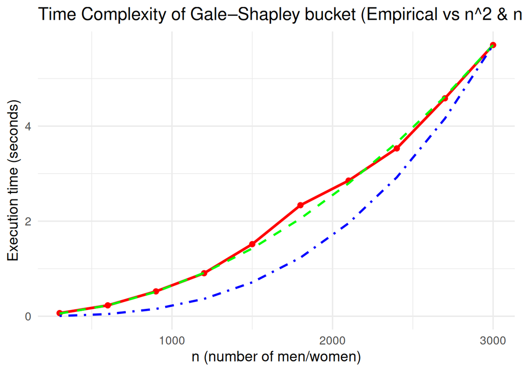

```r
# Choose sizes to test
sizes <- seq(300, 3000, by = 300)
# Measure runtime for each size
times_bucket <- sapply(sizes, test_gs_bucket_time)

# Build data frame for plotting
df <- data.frame(
  n = sizes,
  time = times_bucket,
  n_squared = (sizes^2) / max(sizes^2) * max(times_bucket),          # scaled n²
  n_cubed  = (sizes^3) / max(sizes^3) * max(times_bucket),
  n_log_n  = (sizes * log(sizes)) / max(sizes * log(sizes)) * max(times_bucket)  # scaled n log n
)

# Plot measured time and n^2, n^3 curve
ggplot(df, aes(x = n)) +
  geom_line(aes(y = time), size = 1.2, color = 'red') +
  geom_point(aes(y = time), size = 2, color = 'red') +
  geom_line(aes(y = n_squared), linetype = "dashed", size = 1, color = 'green') +
  geom_line(aes(y = n_cubed), linetype = "dotdash", size = 1, color = 'blue') +
  labs(
    title = "Time Complexity of Gale–Shapley bucket (Empirical vs n^2 & n^3)",
    x = "n (number of men/women)",
    y = "Execution time (seconds)"
  ) +
  theme_minimal(base_size = 14)
```

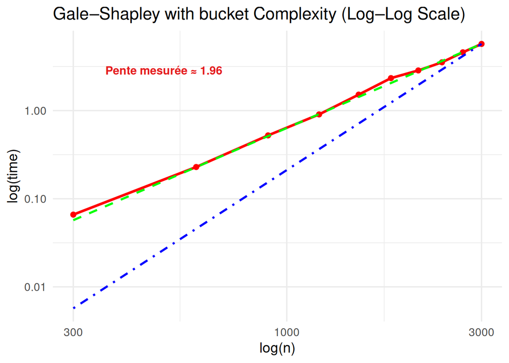

```r
log_time <- log10(df$time)
log_n <- log10(df$n)
model_time <- lm(log_time ~ log_n)
slope_time <- coef(model_time)[2]


ggplot(df, aes(x = n)) +
  geom_line(aes(y = time), size = 1.2, color = 'red') +
  geom_point(aes(y = time), size = 2, color = 'red') +
  geom_line(aes(y = n_squared), linetype = "dashed", size = 1, color = 'green') +
  geom_line(aes(y = n_cubed), linetype = "dotdash", size = 1, color = 'blue') +
  labs(
    title = "Gale–Shapley with bucket Complexity (Log–Log Scale)",
    x = "log(n)",
    y = "log(time)"
  ) +
  scale_x_log10() +
  scale_y_log10() +
  theme_minimal(base_size = 14)+
  annotate("text", x = 500, y = max(df$time) * 0.5,
           label = sprintf("Pente mesurée ≈ %.2f", slope_time),
           color = "#E41A1C", size = 4, fontface = "bold")
```

### Gale-shapley with bucket vs without

Comparons cette nouvelle version avec l’originale :

```r
df <- data.frame(
  n = sizes,
  time1 = times,
  time2 = times_bucket,
  n_squared = (sizes^2) / max(sizes^2) * max(times),          # scaled n²
  n_cubed  = (sizes^3) / max(sizes^3) * max(times),
  n_log_n  = (sizes * log(sizes)) / max(sizes * log(sizes)) * max(times)  # scaled n log n
)
```

[output not shown]

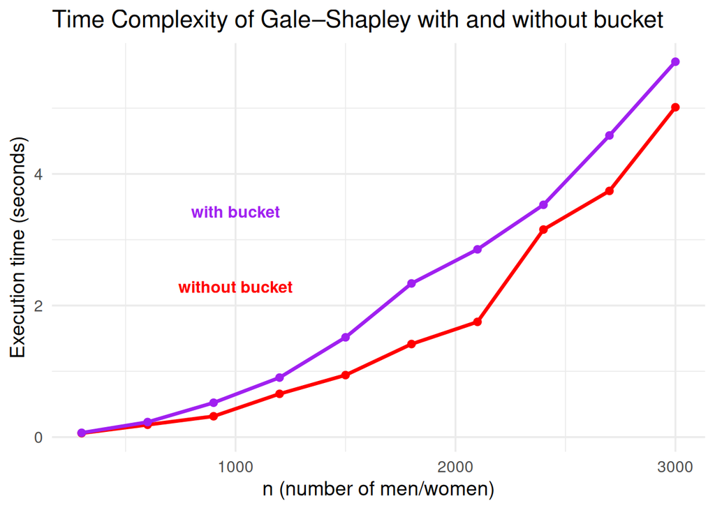

```r
# Plot measured time of gs with and without bucket
ggplot(df, aes(x = n)) +
  geom_line(aes(y = time1), size = 1.2, color = 'red') +
  geom_point(aes(y = time1), size = 2, color = 'red') +
  geom_line(aes(y = time2), size = 1.2, color = 'purple') +
  geom_point(aes(y = time2), size = 2, color = 'purple') +
  labs(
    title = "Time Complexity of Gale–Shapley with and without bucket",
    x = "n (number of men/women)",
    y = "Execution time (seconds)"
  ) +
  theme_minimal(base_size = 14) +
  annotate("text", x = 1000, y = max(df$time2) * 0.6,
           label = print("with bucket"),
           color = "purple", size = 4, fontface = "bold") +
  annotate("text", x = 1000, y = max(df$time2) * 0.4,
           label = print("without bucket"),
           color = "red", size = 4, fontface = "bold")
```

### R vs C++

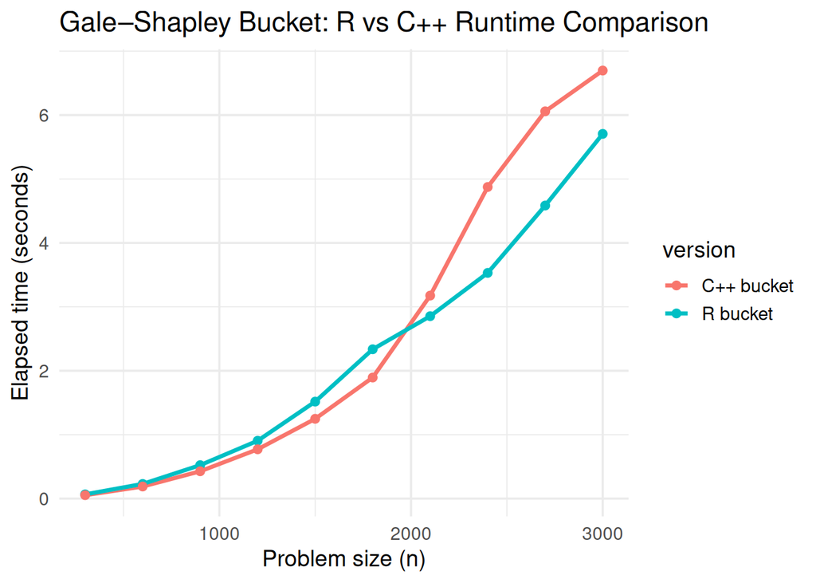

```r
times_r   <- times_bucket
times_cpp <- sapply(sizes, test_gs_bucket_time_cpp)

df <- data.frame(
  n = rep(sizes, 2),
  time = c(times_r, times_cpp),
  version = rep(c("R bucket", "C++ bucket"), each = length(sizes))
)

ggplot(df, aes(x = n, y = time, color = version)) +
  geom_line(size = 1.2) +
  geom_point(size = 2) +
  labs(
    title = "Gale–Shapley Bucket: R vs C++ Runtime Comparison",
    x = "Problem size (n)",
    y = "Elapsed time (seconds)"
  ) +
  theme_minimal(base_size = 14)
```

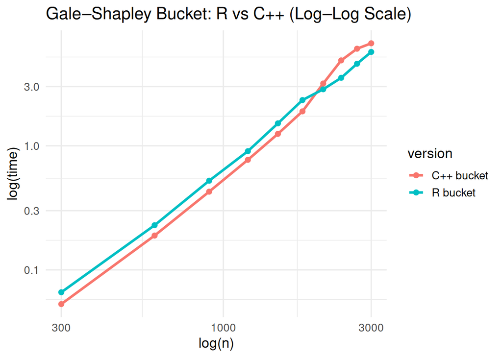

```r
ggplot(df, aes(x = n, y = time, color = version)) +
  geom_line(size = 1.2) +
  geom_point(size = 2) +
  scale_x_log10() +
  scale_y_log10() +
  labs(
    title = "Gale–Shapley Bucket: R vs C++ (Log–Log Scale)",
    x = "log(n)",
    y = "log(time)"
  ) +
  theme_minimal(base_size = 14)
```